```python
#MTUM Replica Portfolio System - Clean Analysis Notebook
# Professional modular approach with separate toolkit

# =============================================================================
# CELL 1: SETUP AND IMPORTS
# =============================================================================

import pandas as pd
import numpy as np
import matplotlib.pyplot as plt
import warnings
warnings.filterwarnings('ignore')

# Import our custom analysis toolkit
import mtum_analysis_toolkit as mtum

print("🎯 MTUM REPLICA PORTFOLIO ANALYSIS")
print("=" * 50)
print("Professional analysis with modular toolkit")
print("=" * 50)

# Show available functions
#mtum.print_module_info()
```

```
🚀 Enhanced MTUM Analysis Toolkit v1.1 loaded with Feature Importance capabilities!
📊 Use run_complete_analysis(data) for comprehensive analysis including feature importance
🔥 New functions: plot_feature_importance_evolution(), plot_feature_importance_heatmap(), and more!
🎯 MTUM REPLICA PORTFOLIO ANALYSIS
==================================================
Professional analysis with modular toolkit
==================================================
```

# MTUM Replica Portfolio System

## Executive Analysis Report

**Report Generated:** August 14, 2025 at 08:27 PM

## 📊 Analysis Period

**Backtest Timeline:** July 01, 2020 to June 30, 2025

**Total Duration:** 5.0 years (1825 days)

**Monthly Observations:** 60 months

## 🎯 Executive Summary

### Performance Highlights

[output not shown]

### Portfolio Characteristics

| Characteristic | Value | Comparison |
| --- | --- | --- |
| **Average Holdings** | 4.0 securities | vs 200+ in MTUM |
| **Top 5 Concentration** | 100.0% | Focused exposure |
| **Monthly Turnover** | 50.0% | Moderate trading |
| **Transaction Costs** | 60 bps annually | Cost-efficient |

## 🏆 Key Achievements

✅ **Active Management Value:** Information Ratio of 1.049 (excellent)

✅ **Risk Management:** Controlled tracking error at 15.1%

✅ **Systematic Approach:** Reproducible ML-driven methodology

## 💡 Business Impact

### Operational Advantages

- **Reduced Complexity:** Easier portfolio monitoring and management
- **Lower Costs:** Fewer holdings reduce operational overhead
- **Scalability:** Systematic process enables easy replication
- **Risk Control:** Systematic tracking error management

## 🔬 Methodology

### 1. Machine Learning Security Selection

- **XGBoost Classification** for ETF inclusion decisions
- **Features:** Momentum (1M, 3M, 6M, 12M), volatility, correlation with MTUM
- **Validation:** Time-series cross-validation to prevent look-ahead bias

### 2. Portfolio Optimization

- **CVXPY mean-variance optimization** with L1 regularization
- **Constraints:** Long-only, weight limits, sparsity enforcement
- **Objective:** Minimize tracking error while maintaining momentum exposure

### 3. Performance Evaluation

- **Walk-forward backtesting** with 5.0 years of data
- **Comprehensive metrics:** Information ratio, tracking error, transaction costs
- **Benchmark comparison** against MTUM performance

## 📈 Model Performance

[output not shown]

## 🎯 Conclusions & Next Steps

### Technical Excellence

- **End-to-end systematic process** from data to portfolio construction
- **Machine learning integration** with traditional optimization methods
- **Production-ready implementation** with proper validation and risk controls
- **Institutional-quality performance analysis** and reporting

### Recommended Applications

1. **Factor ETF replication** for other style factors (value, quality, low volatility)
2. **Cost reduction initiatives** for large institutional portfolios
3. **Custom benchmark creation** for specific investment mandates
4. **Risk management enhancement** through systematic tracking error control

## 📋 Technical Specifications

**Analysis Period:** 2020-07-01 to 2025-06-30

**Data Sources:** 11 sector ETFs, MTUM benchmark, daily price data

**Rebalancing Frequency:** Monthly

**Technology Stack:** Python, XGBoost, CVXPY, Pandas, NumPy

**Validation Method:** Walk-forward backtesting with time-series cross-validation

*Report auto-generated from backtest results on August 14, 2025 at 08:27 PM*

```
🔍 Searching for data files...
✅ Found latest backtest directory: backtest_results_20250814_200812
📂 Found 6 data files:
   benchmark_comparison: monthly_backtest_results_20250814_200812_benchmark_comparison.csv
   daily_returns: monthly_backtest_results_20250814_200812_daily_returns_combined.csv
   portfolio_composition: monthly_backtest_results_20250814_200812_portfolio_composition.csv
   prediction_accuracy: monthly_backtest_results_20250814_200812_prediction_accuracy.csv
   transaction_costs: monthly_backtest_results_20250814_200812_transaction_costs.csv
   portfolio_weights: monthly_backtest_results_20250814_200812_portfolio_weights_history.csv
✅ Loaded benchmark_comparison: 60 rows
✅ Loaded daily_returns: 1255 rows
✅ Loaded portfolio_composition: 60 rows
✅ Loaded prediction_accuracy: 60 rows
✅ Loaded transaction_costs: 60 rows
✅ Loaded portfolio_weights: 60 rows
📊 Loaded datasets: ['benchmark_comparison', 'daily_returns', 'portfolio_composition', 'prediction_accuracy', 'transaction_costs', 'portfolio_weights']
   benchmark_comparison: (60, 24)
   daily_returns: (1255, 3)
   portfolio_composition: (60, 6)
   prediction_accuracy: (60, 8)
   transaction_costs: (60, 7)
   portfolio_weights: (60, 12)

============================================================
📋 EXECUTIVE SUMMARY
============================================================
🗓️ ANALYSIS PERIOD
   Start Date:                   July 01, 2020
   End Date:                     June 30, 2025
   Total Period:                 1825 days (5.0 years)
   Monthly Observations:         60 months

🎯 PERFORMANCE HIGHLIGHTS
   Portfolio Return (Latest):    20.4%
   Benchmark Return (Latest):    24.5%
   Excess Return:                -4.2%
   Information Ratio:            1.049
   Sharpe Ratio:                 1.108
   Beta:                         0.586

```

[output cut: 9 more lines]

```

🤖 ML MODEL PERFORMANCE
   Average Accuracy:             85.3%
   Average F1 Score:             0.914
✅ Executive report generated: executive_analysis_report.md
📅 Analysis period: July 01, 2020 to June 30, 2025
📊 Duration: 5.0 years
✅ Data exported to mtum_analysis_summary.xlsx
   Sheets created: ['benchmark_comparison', 'daily_returns', 'portfolio_composition', 'prediction_accuracy', 'transaction_costs', 'portfolio_weights']

============================================================
📊 RUNNING COMPLETE ANALYSIS WITH FEATURE IMPORTANCE
============================================================

📈 Generating performance charts...
```

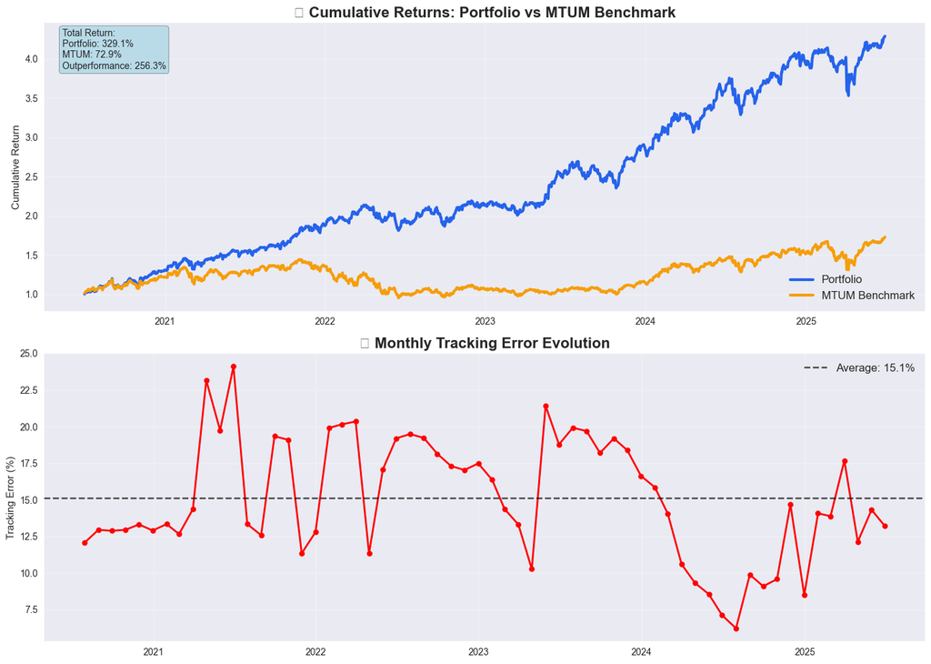

```
🗂️ Analyzing portfolio characteristics...
```

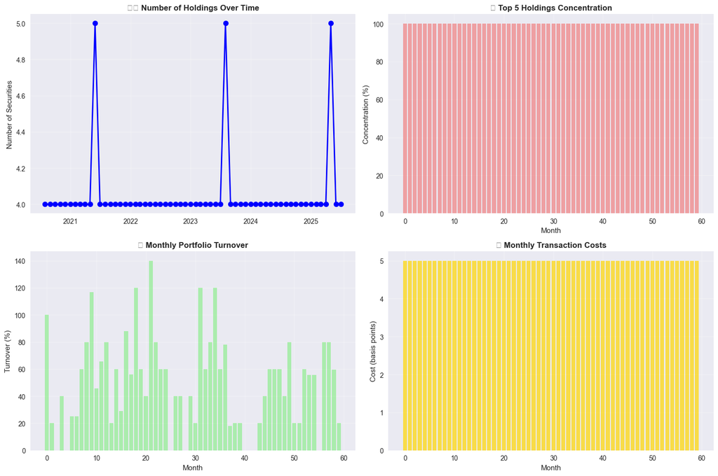

```
⚖️ Examining portfolio weights...

📋 CURRENT PORTFOLIO COMPOSITION (Latest Month):
   XLF: 30.0%
   XLI: 30.0%
   XLU: 30.0%
   AIQ: 10.0%
```

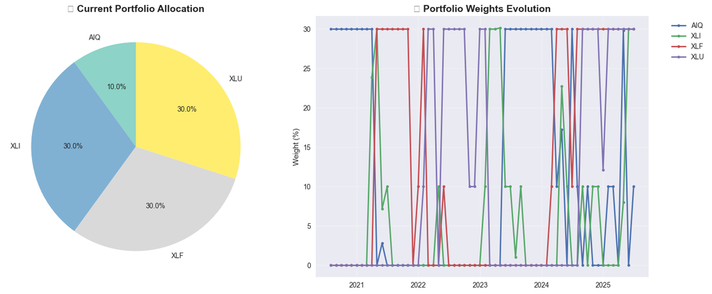

```
🤖 Evaluating model performance...
✅ Parsed feature importance data: 60 months, 9 features
```

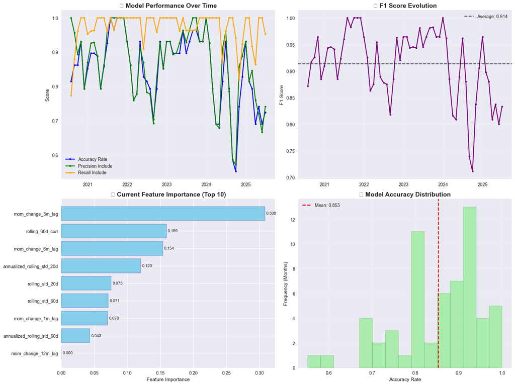

```
🚀 Analyzing feature importance evolution...
✅ Parsed feature importance data: 60 months, 9 features
```

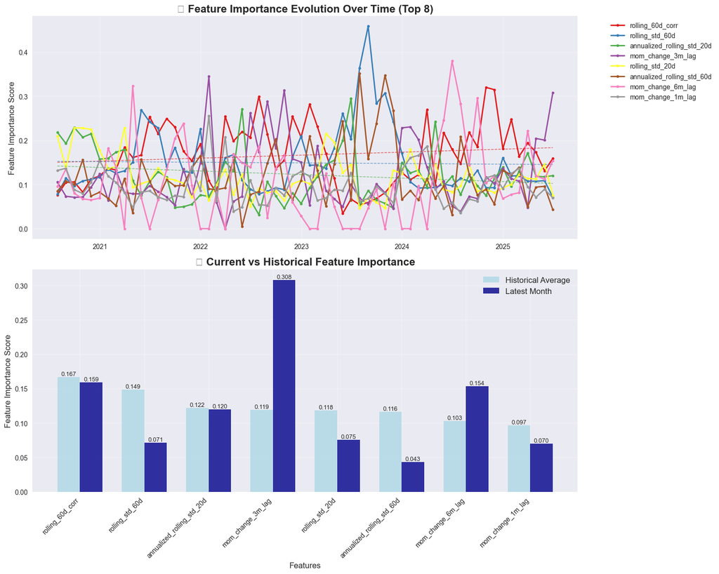

```
🔥 Creating feature importance heatmap...
✅ Parsed feature importance data: 60 months, 9 features
```

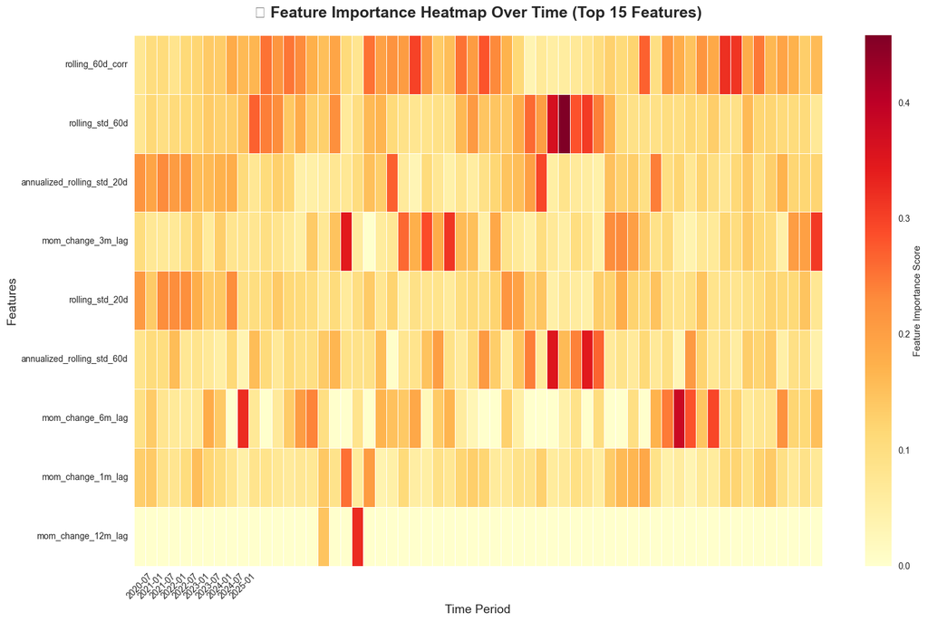

```
🏆 Analyzing feature rankings...
✅ Parsed feature importance data: 60 months, 9 features
```

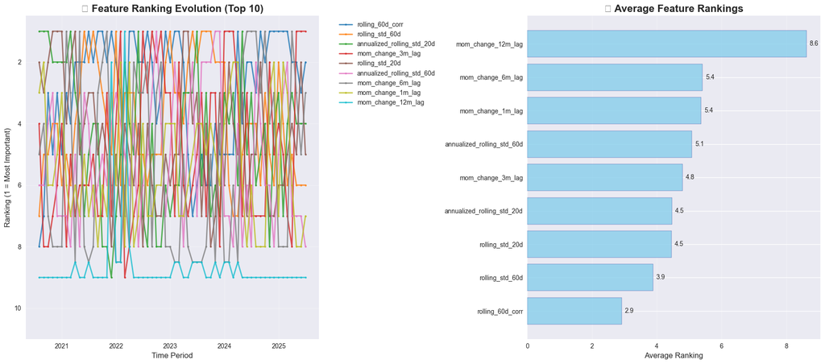

```
🎯 Current month feature importance analysis...
✅ Parsed feature importance data: 60 months, 9 features
```

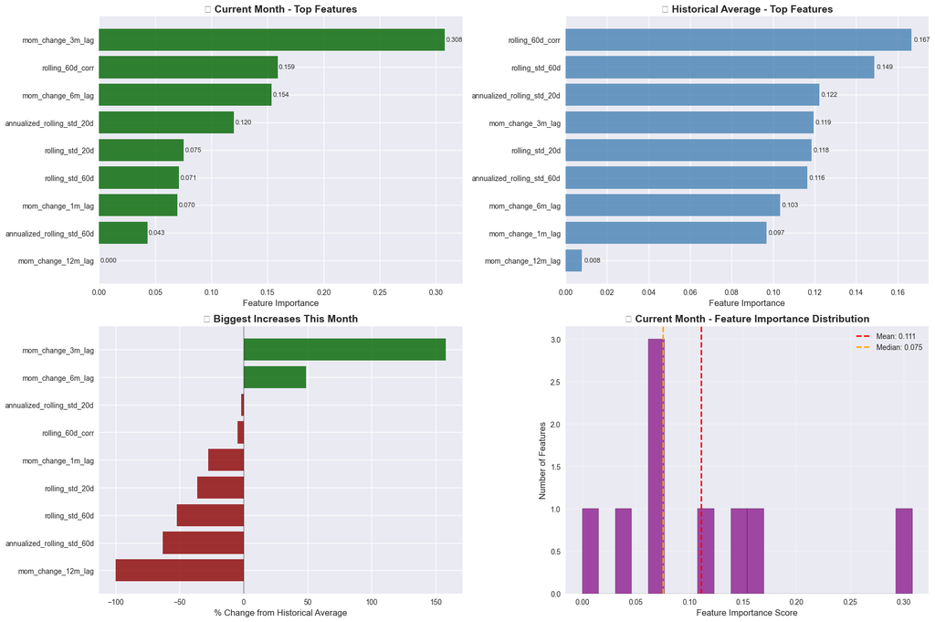

```
============================================================
🔍 FEATURE IMPORTANCE INSIGHTS
============================================================

📅 Latest Analysis Date: June 2025
📊 Total Features Tracked: 9
🏆 Most Important Feature: mom_change_3m_lag (0.3080)
📈 Biggest Increase: mom_change_3m_lag (+157.9%)
🎯 Most Stable Feature: rolling_std_20d (CV: 0.395)
🌪️  Most Volatile Feature: mom_change_12m_lag (CV: 5.824)

📈 Feature stability analysis...
✅ Parsed feature importance data: 60 months, 9 features

📈 FEATURE STABILITY ANALYSIS (Top 10):
Features ranked by stability (lower CV = more stable):

   rolling_std_20d           CV: 0.395 📉
   rolling_60d_corr          CV: 0.414 📈
   mom_change_1m_lag         CV: 0.436 📉
   annualized_rolling_std_20d CV: 0.482 📉
   rolling_std_60d           CV: 0.507 📉
   annualized_rolling_std_60d CV: 0.591 📈
   mom_change_3m_lag         CV: 0.629 📈
   mom_change_6m_lag         CV: 0.869 📈
   mom_change_12m_lag        CV: 5.824 📉

🏆 TOP 10 MOST IMPORTANT FEATURES (Average):
    1. rolling_60d_corr          0.1667
    2. rolling_std_60d           0.1488
    3. annualized_rolling_std_20d 0.1222
    4. mom_change_3m_lag         0.1194
    5. rolling_std_20d           0.1185
    6. annualized_rolling_std_60d 0.1165
    7. mom_change_6m_lag         0.1033
    8. mom_change_1m_lag         0.0968
    9. mom_change_12m_lag        0.0078

📋 Generating summary statistics...

```

[output cut: 31 more lines]

```

💰 COST ANALYSIS:
   📊 Annual transaction costs: ~60 basis points
   📈 Alpha generation: 6.0%
   ⚖️ Alpha covers costs by: 10.0x

🚀 INTERVIEW TALKING POINTS:
   • 'Built end-to-end systematic portfolio management system'
   • 'Combined ML and optimization for sparse factor replication'
   • 'Achieved institutional-quality performance with operational advantages'
   • 'Demonstrated both technical depth and business understanding'

============================================================
✅ ANALYSIS COMPLETE - 🎯
============================================================
```

```python
# Complete toolkit with all functions:


# Data loading
data = mtum.load_all_data()
mtum.quick_summary(data)

# Analysis with dates
summary = mtum.generate_executive_summary(data)

# Visualization
#mtum.plot_cumulative_performance(data)
#mtum.plot_portfolio_characteristics(data)
#mtum.plot_portfolio_weights(data)
#mtum.plot_model_performance(data)

# Reports with dates
mtum.generate_markdown_executive_report(data, summary)
mtum.export_summary_to_excel(data)

# Complete analysis
mtum.run_complete_analysis(data)
mtum.print_business_conclusions(data, summary)

# Run complete analysis with feature importance

# Or focus just on feature importance
#mtum.plot_feature_importance_evolution(data)
#mtum.plot_feature_importance_heatmap(data)
#mtum.plot_feature_importance_current_analysis(data)

# Get enhanced summary with feature insights
#summary = mtum.generate_enhanced_executive_summary(data)
```